# Relatório Bázico

Matheus Martins Santos

2023-04-22

## Passos iniciais

### Bibliotecas

```r
library(readxl) # importar dados do Excel para o R
library(dplyr) # pacote para manipulação de dados
library(nortest) # pacote para realização de testes de normalidade
library(rpart) # pacote para construção de árvores de decisão
library(rpart.plot) # pacote para visualização de árvores de decisão construídas com o rpa
library(knitr) # Usado para produzir relatórios dinâmicos e reprodutíveis
library(kableExtra) # pacote é usado para produzir tabelas atraentes e personalizadas
library(DT)
```

### Importando dados

```r
setwd("F:\\bazico") # Diretorio de trabalho
clientes <- read_excel("clientes.xlsx")
vendas_de_produtos <- read_excel("vendas_de_produtos.xlsx")
```

### Preparação dos Dados

```r
### convertendo as variaveis em numerico e fatores, númericas e Data
vendas_de_produtos$ID_Cliente = as.factor(vendas_de_produtos$ID_Cliente)
vendas_de_produtos$ID_Produto = as.factor(vendas_de_produtos$ID_Produto)
vendas_de_produtos$ID_Pedido = as.factor(vendas_de_produtos$ID_Pedido)

vendas_de_produtos$Quantidade = as.numeric(vendas_de_produtos$Quantidade)
vendas_de_produtos$Desconto = as.numeric(vendas_de_produtos$Desconto)
vendas_de_produtos$Frete = as.numeric(vendas_de_produtos$Frete)
vendas_de_produtos$Total_do_Pedido = as.numeric(vendas_de_produtos$Total_do_Pedido)
vendas_de_produtos$Data <- as.Date(vendas_de_produtos$Data)
```

Foi preciso converter os dados originais em fatores para as variaveis de (ID_Cliente,ID_Produto,ID_Pedido), da mesma forma foi convertido em variáveis númericas (Quantidade,Desconto,Frete,Total_do_Pedido) e em formato de Data a variavel (Data).

### Organizando base Para trabalhar

Em seguida, tive o objetivo de consolidar a base, onde foi agrupada por cliente e por Data de compra, com isso teria uma visão maior sobre o quanto o cliente comprou e o quanto pagou pelas compras, a quantidade de visitas na loja (Variável importante para definir se o cliente já fez um recompra na loja). Por fim, buscou juntar as informações de cada cliente com a localidade que o cliente reside, com base na tabela “Cliente”.

```r
# Agrupando base por cliente e Data de compra;
# em seguinda, soma a quantidade de produto que o cliente comprou
# Soma o valor unitario de cada produto
# Calcula os descontos e frete
base1 <- vendas_de_produtos %>%
  mutate(valor_compra = Quantidade * Preço_Unitário) %>%
  group_by(ID_Cliente, Data) %>%
  summarise(Quantidade = sum(Quantidade),
            valor_compra = sum(valor_compra),
            Desconto = mean(Desconto),
            Frete = mean(Frete))

# Calculando o valor final da compra por cliente e data
# criando a variavel LifeTime value (LTV)
base1 <- base1 %>%
  mutate(valor_final_compra = (valor_compra - Desconto + Frete)) %>%
  group_by(ID_Cliente) %>%
  mutate(LTV = sum(valor_final_compra))

# Conta a quantidade de vezes que o cliente comprou na loja
base1 <- base1 %>%
  group_by(ID_Cliente) %>%
  mutate(quantidade_compras = n())

### Criando a variavel 'Recompra" que representa seo cliente já comprou ou não na loja
base1 <- base1 %>%
  group_by(ID_Cliente) %>%
  mutate(Recompra_Loja = ifelse(quantidade_compras >= 2, "Sim","Não"))

### Juntando a base organizada com a base de clientes
base <- merge(clientes,base1 ,by = "ID_Cliente")
base <- na.omit(base) # retira os valores faltantes.

# Convertendo variaveis em fator
base$Bairro <-  as.factor(base$Bairro)
base$Cidade <-  as.factor(base$Cidade)
base$Estado <-  as.factor(base$Estado)
base$Recompra_Loja = factor(base$Recompra_Loja, levels = c("Sim","Não"))
```

## Obtendo Insights

### avaliando a base de cliente por Cidade/Estado

Estatistica por estado

| Estado | Quantidade de Cliente | % Cliente | Média LTV | Mediana LTV |
| --- | --- | --- | --- | --- |
| SE | 6340 | 85.61% | 1193.17 | 683.80 |
| BA | 262 | 3.54% | 1197.10 | 855.53 |
| SP | 171 | 2.31% | 750.72 | 452.00 |
| PE | 103 | 1.39% | 706.42 | 478.21 |
| CE | 66 | 0.89% | 746.00 | 417.01 |
| PB | 62 | 0.84% | 2041.84 | 1100.79 |
| AL | 53 | 0.72% | 699.57 | 582.50 |
| RJ | 53 | 0.72% | 559.70 | 357.00 |
| RN | 42 | 0.57% | 811.41 | 731.91 |
| MG | 41 | 0.55% | 1182.56 | 462.07 |
| DF | 37 | 0.5% | 737.19 | 491.97 |
| PR | 35 | 0.47% | 906.64 | 1114.00 |
| SC | 26 | 0.35% | 633.67 | 528.91 |
| RS | 25 | 0.34% | 776.95 | 681.60 |
| GO | 18 | 0.24% | 703.37 | 398.94 |
| ES | 14 | 0.19% | 915.14 | 1053.55 |
| MA | 14 | 0.19% | 350.48 | 351.90 |
| MS | 10 | 0.14% | 1641.10 | 1797.00 |
| AC | 8 | 0.11% | 607.15 | 676.58 |
| PI | 8 | 0.11% | 1127.59 | 756.86 |
| AM | 5 | 0.07% | 1121.43 | 526.42 |
| MT | 4 | 0.05% | 953.65 | 997.17 |
| PA | 3 | 0.04% | 304.03 | 302.11 |
| RO | 3 | 0.04% | 1200.87 | 1200.87 |
| TO | 2 | 0.03% | 301.86 | 301.86 |
| RR | 1 | 0.01% | 205.60 | 205.60 |

Top 10 Cidades: Estatistica

| Cidade | Quantidade de Cliente | % Cliente | Média LTV | Mediana LTV |
| --- | --- | --- | --- | --- |
| Aracaju | 6098 | 82.34% | 1205.97 | 692.00 |
| Salvador | 184 | 2.48% | 1337.16 | 928.92 |
| São Paulo | 93 | 1.26% | 765.22 | 547.20 |
| Barra dos Coqueiros | 62 | 0.84% | 1479.65 | 1190.00 |
| Recife | 48 | 0.65% | 648.73 | 544.69 |
| João Pessoa | 47 | 0.63% | 2386.71 | 833.00 |
| Fortaleza | 46 | 0.62% | 849.25 | 417.01 |
| Maceió | 45 | 0.61% | 740.43 | 710.33 |
| Brasília | 37 | 0.5% | 737.19 | 491.97 |
| Rio de Janeiro | 36 | 0.49% | 614.37 | 395.62 |

## Árvore de Decisão - Decision Tree

### dividindo a base em treino e teste

Foi considerando uma proporção de 80% para a base de treinamento, assim o modelo terá mais dados para poder aprender.

```r
# definir a proporção do conjunto de treinamento
prop_treino <- 0.8

# definir uma semente aleatória para reprodutibilidade
set.seed(124)
# criar um vetor de índices aleatórios para dividir a base em treino e teste
indices <- sample(nrow(base), nrow(base)*prop_treino)

# selecionar as observações para o conjunto de treinamento
dados_treino <- base[indices,]

# selecionar as observações para o conjunto de teste
dados_teste <- base[-indices,]
```

### Gerando o modelo com a base de treinamento

```r
# MODELO DE arvore de Decisão ====
fit = rpart(Recompra_Loja ~ Data+Quantidade+Desconto+Frete+valor_final_compra+LTV,
            method = "class",
            data = dados_treino)
```

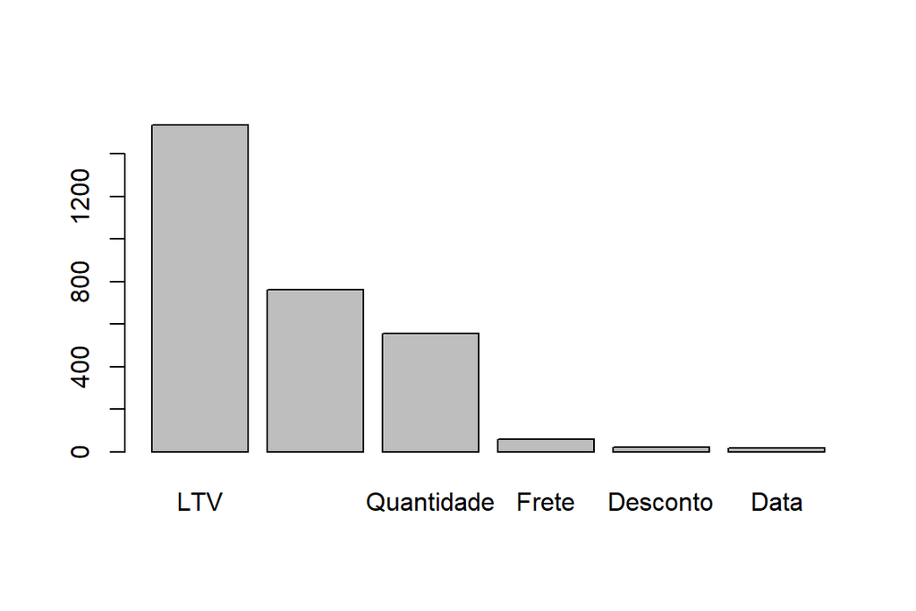

```r
barplot(fit$variable.importance)
```

A tabela de CPs mostra os valores do parâmetro de complexidade que foram testados durante a poda do modelo. A medida que o CP diminui, mais nós são adicionados à árvore, aumentando a complexidade do modelo. A medida que o CP aumenta, mais nós são podados, diminuindo a complexidade do modelo e evitando o overfitting. O valor de CP que produziu o modelo final foi de 0,01.. Abaixo é apresetado um gráfico dos CP e o Erro relativo

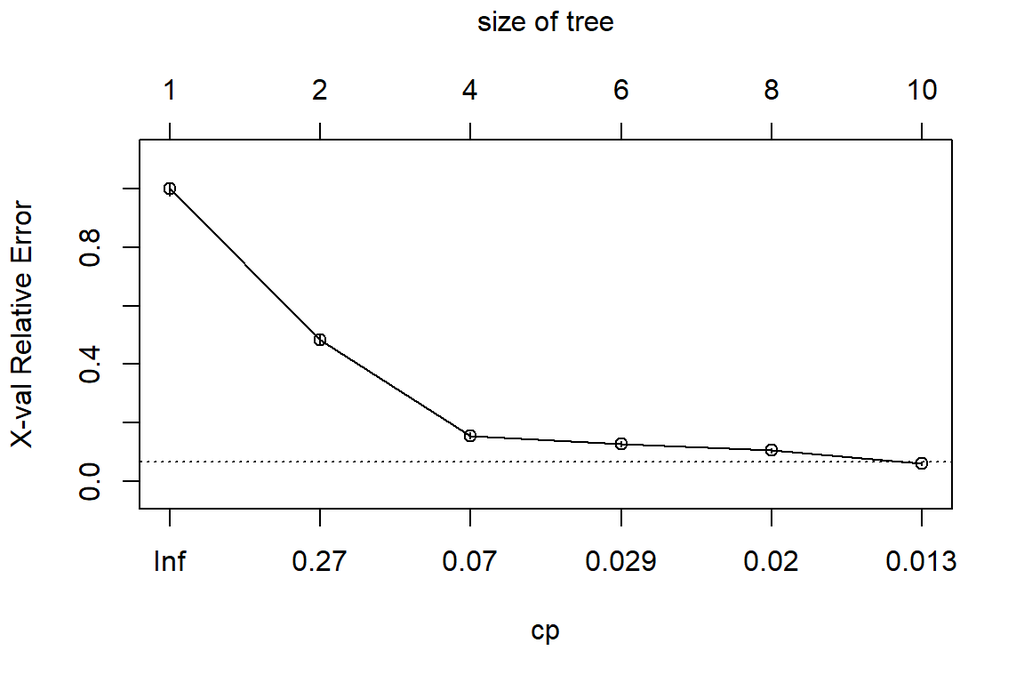

```r
plotcp(fit)
```

### Plotando o modelo

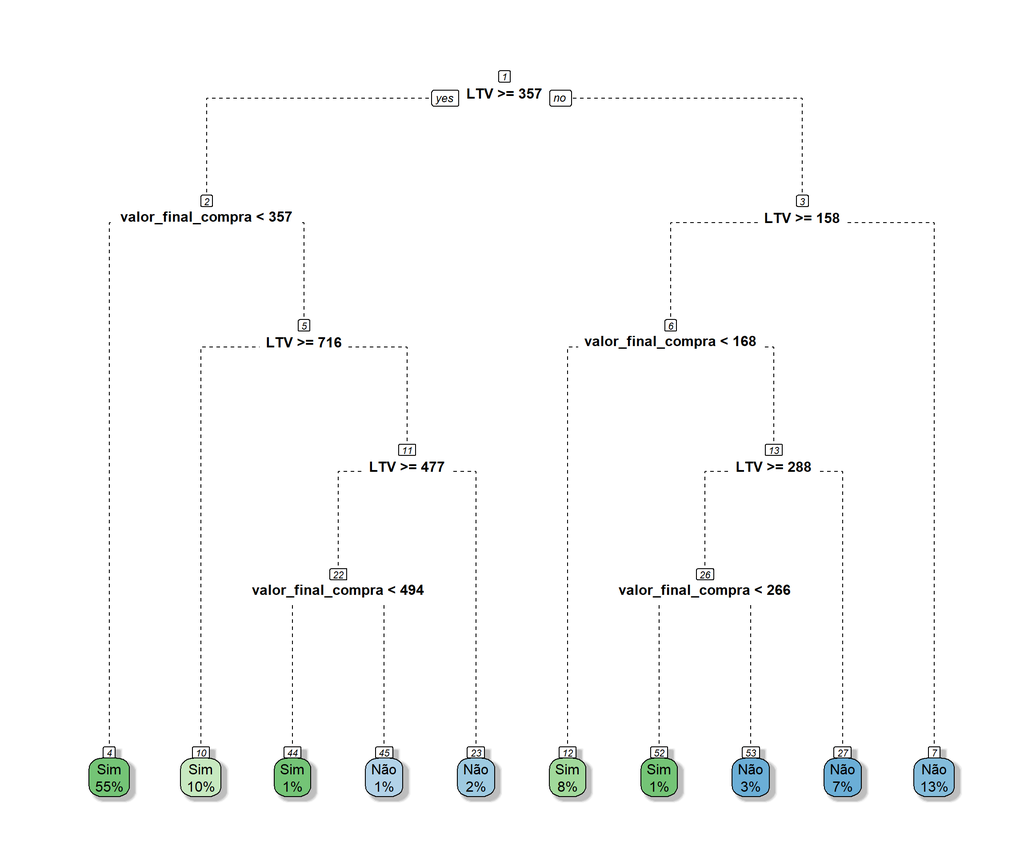

```r
rpart.plot(fit, # method graph
           type = 0,
           extra = 100,
           box.palette = 'GnBu',
           branch.lty = 2,
           shadow.col = "gray",
           nn = TRUE,
           cex = 1)
```

### Interpretação do modelo

Esse modelo foi modelado para prever se um cliente fará uma recompra ou não com base em duas variáveis: LTV (Lifetime Value, valor de vida útil) e valor final da recompra. A árvore tem um nó raiz, que contém o total de observações usadas para construir o modelo (5924), a proporção de observações que fizeram uma recompra (0.745) e a proporção que não fizeram uma recompra (0.255).

Se LTV for menor que 357, a árvore segue para o terceiro nó, que testa se o LTV é maior ou igual a 158. Se for menor, a árvore prevê que o cliente não fará uma compra (prob = 51,7%), caso contrário, a árvore segue para o 6º nó, que testa se o valor final da compra é menor que 168, se for o caso, o árvore prevê que o cliente fará uma recompra (prob = 99,5), caso contrário, se o valor final da compra for maior que 168, o modelo segue para o 13º nó, onde testa se o LTV é maior ou igual a 288, se for menor, a árvore prevê que o cliente não fará uma recompra (prob = 99,5%), se for maior, o modelo segue para o 26º nó, que testa se o valor final da compra é menor que 266, se for o caso, a árvore prevê que o cliente fará uma recompra (prob = 100%), caso contrário o modelo prevê que o cliente não fará uma recompra (prob = 100%).

## Predição

### Utilizado o modelo treinado com a base teste para testar se o modelo está fazendo boa previsões.

```r
predicao_teste <- predict(fit, newdata = dados_teste, type = "class")
```

### Matriz de confusão

```r
matriz_confusao <- table(predicao_teste, dados_teste$Recompra_Loja)
```

[output not shown]

Interpretando a matriz de confusão, temos que:

- O modelo classificou corretamente 1082 clientes como verdadeiros positivos, ou seja, previu corretamente que esses clientes farão uma recompra.
- O modelo classificou corretamente 372 clientes como falso verdadeiro, ou seja, previu corretamente que esses clientes não farão uma recompra.
- O modelo classificou incorretamente 10 clientes como falsos positivo, ou seja, previu incorretamente que esses clientes farão uma recompa, quando na verdade eles não fizeram.r
- O modelo classificou incorretamente 18 clientes como falsos negativos, ou seja, previu incorretamente que esses clientes não farão uma recompra, quando na verdade eles fizeram.s.

### Acurácia

```r
acuracia <- sum(diag(matriz_confusao))/sum(matriz_confusao)
round(acuracia,4)*100
```

```
## [1] 98.11
```

A acurácia é uma métrica de avaliação de modelos de classificação que mede a proporção de observações classificadas corretamente pelo modelo em relação ao total de observações. Em outras palavras, a acurácia representa a capacidade do modelo de classificar corretamente as observações em todas as classes. Desse modo, o modelo apresentou uma acertividade de 98,11% das observações.

### Prevendo as probabilidades dos clientes fazer uma recompra

```r
# fazer a previsão das probabilidades de recompra para o conjunto de teste
probabilidade_teste <- predict(fit, newdata = dados_teste, type = "prob")
```

### Juntando as probabilidades ao conjuntos de teste e imprimindo a lista do cliente mais provavéis

```r
# juntar as probabilidades previstas ao conjunto de teste
dados_teste_com_prob <- cbind(dados_teste, probabilidade_teste[,1])

# renomeando nome da coluna
colnames(dados_teste_com_prob)[ncol(dados_teste_com_prob)] <- "probabilidade_recompra"

# imprimindo a tabela
df <- dados_teste_com_prob %>%
  select(ID_Cliente, probabilidade_recompra) %>%
  group_by(ID_Cliente) %>%
  summarise(probabilidade = round(mean(probabilidade_recompra),4)) %>%
  arrange(desc(probabilidade))

datatable(df,
          caption = 'Previsões dos Cliente mais propensos a fazer uma recompra a menos propensos',
          rownames = FALSE,
          class = 'display nowrap compact',
          extensions = 'Scroller',
          options = list(dom = 't',
                         deferRender = TRUE,
                         scrollY = 400,
                         scroller = TRUE,
                         scrollX = TRUE,
                         scrollCollapse = TRUE,
                         fixedColumns = TRUE,
                         pageLength = 50))
```

| ID_Cliente | probabilidade |
| --- | --- |
| 12268398905 | 1 |
| 12383202291 | 1 |
| 12383340726 | 1 |
| 12383774078 | 1 |
| 12384988715 | 1 |
| 12385092320 | 1 |
| 12419503756 | 1 |
| 12428854910 | 1 |
| 12429082030 | 1 |
| 12429263068 | 1 |

[output cut: 1118 more lines]